# Intuit Trees

- Team-lead GitLab id: 1538666
- Team-lead GitLab username: rsm3-yuc535
- Group number: 6
- Group name: friends
- Team member names: Yunru Cao, Yingwen Chen, Vishnu Sharon, Kaushik Vijayakumar

## Setup

Please complete this R-markdown document with your group by answering the questions in `intuit-trees.pdf` on Dropbox (week7/readings/). Create an HTML file with all your results and comments and push both the Rmarkdown and HTML file to GitLab when your team is done. All results MUST be reproducible (i.e., the TA and I must be able to recreate the HTML from the Rmarkdown file without changes or errors).

This is the second group assignment for MGTA 455 and you will be using git and GitLab. If two people edit the same file at the same time you could get what is called a “merge conflict”. git will not decide for you who’s change to accept so the team-lead will have to determine which edits to use. To avoid merge conflicts, always click “pull” in Rstudio before you start working on file. Then, when you are done, commit your changes, and push them to GitLab. Make this a habit!

If multiple people are going to work on the assignment at the same time I recommend you work on different files. You can use `source` to include R-code in your Rmarkdown document or include other R(markdown) documents into the main assignment file.

Group work-flow tips are listed from ICT in summer are shown below:

- Pull, edit, save, stage, commit, and push
- Schedule who does what and when
- Try to avoid working simultaneously on the same file
- If you are going to work simultaneously, do it in different files, e.g.,
  - assignment1_john.R, assignment1_susan.R, assignment1_wei.R
  - assignment1a.R, assignment1b.R, assignment1c.R
- Use the ‘source’ command to bring different pieces of code together in an Rmarkdown document or in an R-code file
- Alternatively, use *child* in Rmarkdown to include a part of a report
- For (very) big projects use ‘branches’ to avoid conflicts (and stay on your branch)

A graphical depiction of the group work-flow is shown below:

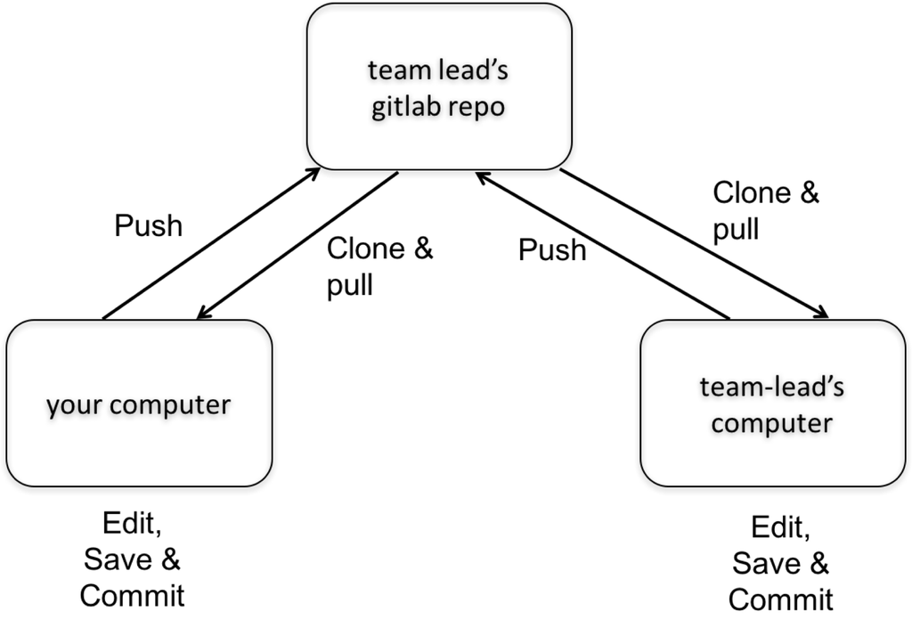

Additional resource on the use of git are linked below:

- http://happygitwithr.com
- http://r-pkgs.had.co.nz/git.html
- http://stackoverflow.com/questions/tagged/git or just a google search
- https://try.github.io
- https://www.manning.com/books/git-in-practice
- https://github.com/GitInPractice/GitInPractice#readme

```r
## loading the data. Note that data must be loaded from the data/
## in the rstudio project directory
intuit75k_wrk <- readr::read_rds("data/intuit75k.rds")

## Recall that Radiant stores all datasets in a list called r_data
## if you are planning to use data transformation commands generated by Radiant
## uncomment the lines below and comment out the line above
# if (!exists("r_data")) r_data <- list()
# r_data[["intuit75k_wrk"]] <- readr::read_rds("data/intuit75k.rds")
```

## Question answers

```r
library(tidyverse)
library(caret)
```

#### change the zip-bins

```r
intuit75k_wrk <- intuit75k_wrk %>%
  mutate(zip801 = ifelse(zip == "00801",TRUE,FALSE),
         zip804 = ifelse(zip == "00804",TRUE,FALSE))

intuit75k_wrk$zip_bins <- as.factor(intuit75k_wrk$zip_bins)
```

#### filter the data

```r
### training data
intuit_train <- intuit75k_wrk %>%
  filter(training == 1)

### test data
intuit_test <- intuit75k_wrk %>%
  filter(training == 0)
```

### Decision Trees

```r
### train the model
decision_tree <- crtree(dataset = intuit_train, rvar = "res1", evar =  c("sex","bizflag","numords","dollars","last","version1","owntaxprod","upgraded","zip_bins","zip801","zip804"),
                        type = "classification",
                        lev = "Yes",
                        prior = 0.5
                       )
decision_tree_pred <- predict(decision_tree,intuit_test)
intuit_test <- intuit_test %>%
  mutate(pred_decisiontree = decision_tree_pred$Prediction)
result <- confusion(
  dataset = "intuit_test",
  pred = c("pred_decisiontree"),
  rvar = "res1",
  lev = "Yes",
  cost = 1.41,
  margin = 60,
  train = "All"
)
summary(result)
```

```
Confusion matrix
Data       : intuit_test
Results for: All
Predictors : pred_decisiontree
Response   : res1
Level      : Yes in res1
Cost:Margin: 1.41 : 60

 Type         Predictor  TP   FP    TN  FN total   TPR   TNR precision Fscore
  All pred_decisiontree 835 8945 12452 268 22500 0.757 0.582     0.085  0.153

 Type         Predictor accuracy kappa profit index  ROME contact   AUC
  All pred_decisiontree    0.591 0.072 36,310 1.000 2.633   0.435 0.750
```

### Random Forest

```r
set.seed(1234)
model_rf <- train(
  res1 ~ sex+bizflag+numords+dollars+last+version1+owntaxprod+upgraded+zip_bins+zip801+zip804,
  data = intuit_train,
  tuneLength = 5,
  metric = "ROC",
  method = "ranger",
  trControl = trainControl(method = "cv", number = 5, verboseIter = TRUE,summaryFunction = twoClassSummary,classProbs = TRUE)
)
```

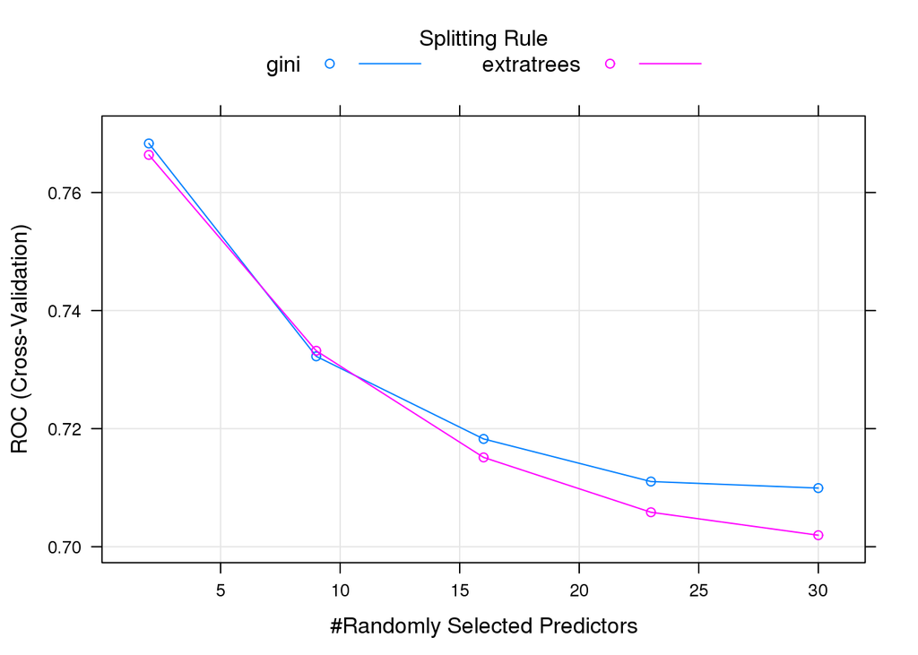

```r
plot(model_rf)
```

```r
rf_pred <- predict(model_rf,intuit_test,type="prob")
intuit_test <- intuit_test %>%
  mutate(pred_rf = rf_pred$Yes)
result <- confusion(
  dataset = "intuit_test",
  pred = c("pred_rf"),
  rvar = "res1",
  lev = "Yes",
  cost = 1.41,
  margin = 60,
  train = "All"
)
summary(result)
```

```
Confusion matrix
Data       : intuit_test
Results for: All
Predictors : pred_rf
Response   : res1
Level      : Yes in res1
Cost:Margin: 1.41 : 60

 Type Predictor   TP    FP  TN FN total   TPR   TNR precision Fscore
  All   pred_rf 1097 20651 746  6 22500 0.995 0.035     0.050  0.096

 Type Predictor accuracy kappa profit index  ROME contact   AUC
  All   pred_rf    0.082 0.003 35,155 1.000 1.146   0.967 0.764
```

### Bagged tree

```r
library(ipred)
set.seed(1234)
model_bag <- bagging(formula = res1 ~ sex+bizflag+numords+dollars+last+version1+owntaxprod+upgraded+zip_bins+zip801+zip804,
                        data = intuit_train,
                        coob = TRUE)

bag_pred <- data.frame(predict(model_bag,intuit_test,type= "prob"))
intuit_test <- intuit_test %>%
  mutate(pred_bag = bag_pred$Yes)
result <- confusion(
  dataset = "intuit_test",
  pred = c("pred_bag"),
  rvar = "res1",
  lev = "Yes",
  cost = 1.41,
  margin = 60,
  train = "All"
)
summary(result)
```

```
Confusion matrix
Data       : intuit_test
Results for: All
Predictors : pred_bag
Response   : res1
Level      : Yes in res1
Cost:Margin: 1.41 : 60

 Type Predictor  TP   FP    TN  FN total   TPR   TNR precision Fscore
  All  pred_bag 747 9419 11978 356 22500 0.677 0.560     0.073  0.133

 Type Predictor accuracy kappa profit index  ROME contact   AUC
  All  pred_bag    0.566 0.048 30,486 1.000 2.127   0.452 0.671
```

### Xgboost

```r
library(radiant)

intuit75k_wrk <- readr::read_rds("data/intuit75k.rds")

intuit <- filter(intuit75k_wrk,training==1)
intuit_test <- filter(intuit75k_wrk,training==0)



intuit$zip801 <- ifelse(substr(intuit$zip,1,3)==801,1,0)

intuit$zip804 <- ifelse(substr(intuit$zip,1,3)==804,1,0)

intuit_test$zip801 <- ifelse(substr(intuit_test$zip,1,3)==801,1,0)

intuit_test$zip804 <- ifelse(substr(intuit_test$zip,1,3)==804,1,0)


vars <- c("zip_bins","numords","dollars","last","version1","upgraded","owntaxprod","zip801","zip804","res1")

intuit <- intuit %>%
          select(vars)

intuit_test <- intuit_test %>%
               select(vars)

intuit$res1 <- ifelse(intuit$res1=="Yes",1,0)

intuit_test$res1 <- ifelse(intuit_test$res1=="Yes",1,0)

intuit_train <- intuit

Cost <- 1.41
Margin <- 60

BreakEven <- Cost/Margin


#-----------------------------------------------------

library(xgboost)
library(data.table)
library(caret)
library(Metrics)

setDT(intuit_train)
setDT(intuit_test)

train <- model.matrix(~.+0,data = intuit_train[,-c("res1"),with=F])
label_train <- intuit_train$res1


test <- model.matrix(~.+0,data = intuit_test[,-c("res1"),with=F])
label_test <- intuit_test$res1


train <- xgb.DMatrix(data = train,label = label_train)
test <- xgb.DMatrix(data = test,label = label_test)


# # TUNING XGB
# best_param <- list()
# best_rmse <- 1
# set.seed(1234)
#
# stime <- Sys.time()
# for (iter in 1:100) {
#   param <- list(
#                 booster = "gbtree",
#                 objective = "binary:logistic",
#                 eval_metric = "rmse",
#                 max_depth = sample(6:10, 1),
#                 eta = runif(1, .01, .3),
#                 gamma = runif(1, 0.0, 0.2),
#                 subsample = runif(1, .6, .9),
#                 colsample_bytree = runif(1, .5, .8),
#                 min_child_weight = sample(1:40, 1),
#                 max_delta_step = sample(1:10, 1)
#   )
#
#
#   cv.nround = 100
#   cv.nfold = 5
#   seed.number = sample.int(1000, 1)[[1]]
#   set.seed(seed.number)
#
#   mdcv <- xgb.cv(data=train, params = param, nthread=6,
#                  nfold=cv.nfold, nrounds=cv.nround, early_stop_round=8, maximize=FALSE)
#
#   min_rmse = min(mdcv$evaluation_log[, train_rmse_mean])
#   min_rmse_index = which.min(mdcv$evaluation_log[, train_rmse_mean])
#
#   if (min_rmse < best_rmse) {
#     best_rmse = min_rmse
#     best_rmse_index = min_rmse_index
#     best_seednumber = seed.number
#     best_param = param
#   }
# }
# etime <- Sys.time()
# etime - stime

opt_param <- list(
                booster = "gbtree",
                objective = "binary:logistic",
                eval_metric = "rmse",
                max_depth = 9,
                eta = 0.1312246,
                gamma = 0.1343104,
                subsample = 0.6195722,
                colsample_bytree = 0.7236733,
                min_child_weight = 1,
                max_delta_step = 4
  )


set.seed(1000)
xgb_opt <- xgb.train (params = opt_param, data = train, nrounds = 34, watchlist = list(val=test,train=train),
                   print_every_n = 1, early_stop_round = 10, maximize = F)
xgbpred_opt <- predict (xgb_opt,test)

xgbpred_opt <- ifelse(label_test==1,xgbpred_opt,xgbpred_opt/2)

xgbpred_opt_decision <- ifelse (xgbpred_opt > BreakEven,1,0)

confusionMatrix (xgbpred_opt_decision, label_test)
```

```
Confusion Matrix and Statistics

          Reference
Prediction     0     1
         0 14773    82
         1  6624  1021

               Accuracy : 0.702
                 95% CI : (0.6959, 0.7079)
    No Information Rate : 0.951
    P-Value [Acc > NIR] : 1

                  Kappa : 0.1616
 Mcnemar's Test P-Value : <0.0000000000000002

            Sensitivity : 0.6904
            Specificity : 0.9257
         Pos Pred Value : 0.9945
         Neg Pred Value : 0.1336
             Prevalence : 0.9510
         Detection Rate : 0.6566
   Detection Prevalence : 0.6602
      Balanced Accuracy : 0.8080

       'Positive' Class : 0
```

```r
wave <- data.frame(xgbpred_opt,label_test,xgbpred_opt_decision)

colnames(wave) <- c("Prob","Actual","Pred")
wave$Wave2 <- ifelse(wave$Actual==0&wave$Pred==1,1,0)

exp_cust<-sum(wave$Pred==1)
exp_buyers<-sum(wave$Pred+wave$Actual==2)
Profit <- Margin * exp_buyers - Cost * exp_cust

AUC_XGB<- auc(actual = wave$Actual,predicted = wave$Pred)

model_xgb <- data.frame(Profit=Profit, AUC = AUC_XGB)
model_xgb$Profit
```

```
[1] 50480.55
```

```r
# WAVE 2 PROFIT

nmail <- sum(wave$Wave2)

exp_resp <- mean(filter(wave,Wave2==1)$Prob)*nmail

wave2Profit <- Margin * exp_resp - Cost * nmail

mailto_wave2 <- wave$Wave2
mailto_wave2 <- ifelse(mailto_wave2==1,TRUE,FALSE)


id <- filter(intuit75k_wrk,training==0)$id


Vishnu_Kaushik_Yunru_Yingwen_Team6 <- data.frame(id,mailto_wave2)
colnames(Vishnu_Kaushik_Yunru_Yingwen_Team6) <- c("id","mailto_wave2")

saveRDS(Vishnu_Kaushik_Yunru_Yingwen_Team6,file="Vishnu_Kaushik_Yunru_Yingwen_Team6.rds")
```

##### We find that xgboost model has the best performance. And use it to predict who to mail in wave2.